# 10 - Reporting Reproducible Research

# Introduction and Setup

For these exercises, we will look at the core concepts from this lesson. As always, load the libraries necessary for this lesson.

```r
library(tidyverse)
library(effsize)
library(TOSTER)
```

For this exercise, we’ll look at doing a full analysis using a data set and report from the excellent [Open Stats Lab](https://sites.trinity.edu/osl).

Schroeder and Epley(2015) explored whether you’d be more likely to get a new job after delivering a speech describing your skills, or if you wrote a speech and had a potential employer read it out.

Prediction: A person’s speech (i.e., vocal tone, cadence, and pitch) communicates information about intelligence better than written words. Participants: 39 professional recruiters in one of two conditions. Conditions: Listen to audio recording of speech, or read speech aloud. Dependent Variable: Intellect aggregated across intelligence, competence, and thoughtfulness.

Also rated overall impression (composite of positive and negative), and how likely they would be to hire them (0 = not at all, 10 = extremely likely).

```r
# unique URL to the data
id <- "0Bz-rhZ21ShvOei1MM24xNndnQ00" # google file ID
# read in the data
raw_data <- read_csv(
  sprintf(
  "https://docs.google.com/uc?id=%s&export=download", id)
  )
```

## Question 1

Subset the data to the columns relevant to the research question, and make the names all lowercase for consistency.

Call this, `data_subset`.

```r
data_subset <- raw_data %>%
  select(CONDITION,
         Intellect_Rating,
         Impression_Rating,
         Hire_Rating
         ) %>%
  mutate(CONDITION = as.factor(CONDITION)) %>%
  rename_all(tolower)
```

## Question 2

Summarise the data, creating means, standard deviations, and ns for each group in the data set. Call this `data_summary`. Put the summary in a table using the `kable()` command.

```r
data_summary <- data_subset %>%
  group_by(condition) %>%
  summarise(mean_intellect = mean(intellect_rating),
            sd_intellect = sd(intellect_rating),
            n = n()
            )
knitr::kable(data_summary)
```

| condition | mean_intellect | sd_intellect | n |
| --- | --- | --- | --- |
| 0 | 3.648148 | 1.911343 | 18 |
| 1 | 5.634921 | 1.608674 | 21 |

## Question 3

Create a plot to display the differences across the groups.

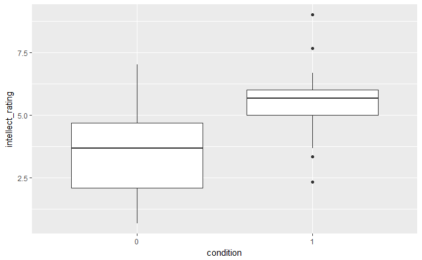

```r
ggplot(data = data_subset,
       mapping = aes(x = condition, y = intellect_rating)
       ) +
  geom_boxplot()
```

## Question 4

Test the assumptions of an independent-samples *t*-test.

```r
# bartlett test
bartlett.test(intellect_rating ~ condition, data = data_subset)
```

```
    Bartlett test of homogeneity of variances

data:  intellect_rating by condition
Bartlett's K-squared = 0.53405, df = 1, p-value = 0.4649
```

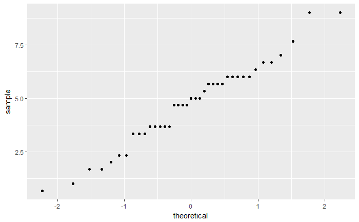

```r
# qq-plot
ggplot(data = data_subset, mapping = aes(sample = intellect_rating)) +
  stat_qq()
```

**Answer**: The homogeneity of variances assumption is met, as is the assumption of normality; therefore we can procede with the independent-samples *t*-test.

## Question 5

Assuming the test assumptions are met, fit a model to your data, save this as `t_test_output`. For this case, we will just look at the effect of Intellect. Output the test on completion. (Note: do not use `summary()` here, instead just type the name of the object.)

```r
t_test_output <- t.test(intellect_rating ~ condition, paired = F, data = data_subset)
t_test_output
```

```
    Welch Two Sample t-test

data:  intellect_rating by condition
t = -3.4787, df = 33.434, p-value = 0.001421
alternative hypothesis: true difference in means is not equal to 0
95 percent confidence interval:
 -3.1481685 -0.8253765
sample estimates:
mean in group 0 mean in group 1
       3.648148        5.634921
```

## Question 6

Calculate effect sizes for the *t*-test. The choice of effect size is up to you.

```r
cohen.d(intellect_rating ~ condition, paired = F, hedges.correction = T, data = data_subset)
```

```
Hedges's g

g estimate: 1.094193 (large)
95 percent confidence interval:
      inf       sup
0.3966294 1.7917572
```

## Question 7

Perform a TOST on your data evaluating the equivalence against a lower bound of -0.5 and upper bound of 0.5. What does this tell us? (Hint: Use the `with()` function on the data_summary object to access the columns for that data source.)

```
Using alpha = 0.05 Student's t-test was significant, t(37) = -3.525933, p = 0.001144441
Using alpha = 0.05 the equivalence test based on Student's t-test was non-significant, t(37) = -2.638581, p = 0.9939454TOST results:
  t-value 1 p-value 1 t-value 2    p-value 2 df
1 -2.638581 0.9939454 -4.413285 4.246274e-05 37

Equivalence bounds (raw scores):
  low bound raw high bound raw
1          -0.5            0.5

TOST confidence interval:
  Lower Limit 90% CI raw Upper Limit 90% CI raw
1              -2.937406              -1.036139
```

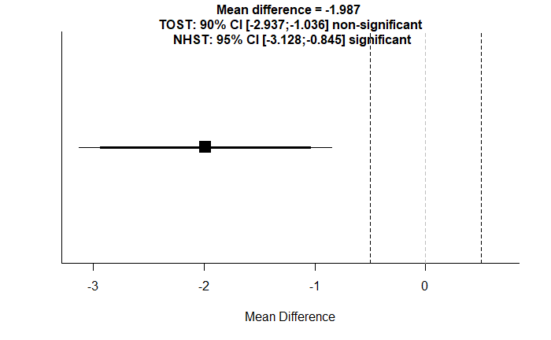

```r
with(data_summary,
     TOSTtwo.raw(m1 = mean_intellect[1],
                 m2 = mean_intellect[2],
                 sd1 = sd_intellect[1],
                 sd2 = sd_intellect[2],
                 n1 = n[1],
                 n2 = n[2],
                 low_eqbound = -0.5,
                 high_eqbound = 0.5,
                 alpha = 0.05,
                 var.equal = TRUE
                 )
     )
```

**Answer**: The NHST is significant, indicating a statistical difference between the groups. The TOST is non-significant, indicating that the two groups are non-equivalent. This means that the difference between groups is large enough for us to care about them.

## Question 8

A. Fit a linear model to the data. Save this as `lm_test_output`. How does this compare with the *t*-test? B. Output 95% confidence intervals for the linear model. Why do they differ to that of the *t*-test?

```r
lm_test_output <- lm(intellect_rating ~ condition, data = data_subset)
summary(lm_test_output)
```

```
Call:
lm(formula = intellect_rating ~ condition, data = data_subset)

Residuals:
    Min      1Q  Median      3Q     Max
-3.3016 -0.9683  0.0185  0.6918  3.3651

Coefficients:
            Estimate Std. Error t value Pr(>|t|)
(Intercept)   3.6481     0.4135   8.823 1.24e-10 ***
condition1    1.9868     0.5635   3.526  0.00114 **
---
Signif. codes:  0 *** 0.001 ** 0.01 * 0.05 . 0.1   1

Residual standard error: 1.754 on 37 degrees of freedom
Multiple R-squared:  0.2515,    Adjusted R-squared:  0.2313
F-statistic: 12.43 on 1 and 37 DF,  p-value: 0.001144
```

```r
confint(lm_test_output)
```

```
                2.5 %   97.5 %
(Intercept) 2.8103640 4.485932
condition1  0.8450652 3.128480
```